# Titanic Survival: Groups, Families, and Women-and-Children-First

CLI Copilot

# Plan and Data

This report analyzes two questions using the Titanic dataset in `data/train.csv` and `data/test.csv`:

- Do travel groups survive together? We examine survival vs ticket-group size, family size, and alone status; and add features GroupSize (count per Ticket), IsAlone, FamilySize to a model, comparing cross-validation to a baseline using Sex, Pclass, Age, Fare.
- How strong is women and children first once you include class? We examine survival by Sex × Age band and Sex × Pclass, and fit logistic regression with interaction terms Sex*Child and Sex*Pclass versus a tree model; compare cross-validation and interpret key effects.

We use tidyverse for manipulation and ggplot2 for plotting with a minimalist style and consistent formatting.

```r
library(tidyverse)
library(broom)
library(rsample)
library(yardstick)
library(glmnet)
library(modelr)
library(knitr)
library(ggthemes)
library(here)
# Read data using project root path
train <- read_csv(here::here("data","train.csv"))
# Basic cleaning: create key features
train <- train %>%
  mutate(
    Sex = factor(Sex),
    Pclass = factor(Pclass),
    FamilySize = SibSp + Parch + 1,
    Ticket = as.character(Ticket),
    # GroupSize: number of passengers sharing the same Ticket
    GroupSize = add_count(., Ticket)$n,
    IsAlone = as.integer(FamilySize == 1),
    # Child: Age < 16; handle missing Age using median by Sex/Pclass
    Age = ifelse(is.na(Age), ave(Age, Sex, Pclass, FUN = function(x) ifelse(all(is.na(x)), median(train$Age, na.rm = TRUE), median(x, na.rm = TRUE))), Age),
    Child = as.integer(Age < 16),
    Survived = factor(Survived, levels = c(0,1), labels = c("No","Yes"))
  )

# minimalist theme
theme_base <- theme_minimal(base_size = 12) + theme(legend.position = "bottom")
```

# 1) Do travel groups survive together

## EDA: Survival vs ticket-group size, family size, and alone status

We investigate whether larger travel groups and families had different survival outcomes, and whether being alone mattered.

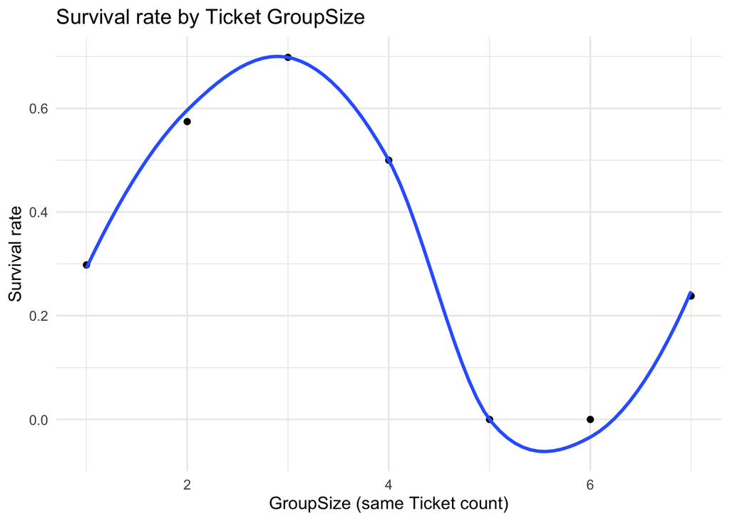

```r
# Group survival rate by GroupSize
eda_group <- train %>%
  group_by(GroupSize) %>%
  summarize(n = n(), surv_rate = mean(Survived == "Yes"), .groups = "drop")

ggplot(eda_group, aes(GroupSize, surv_rate)) +
  geom_point() + geom_smooth(method = "loess", se = FALSE) +
  labs(title = "Survival rate by Ticket GroupSize",
       x = "GroupSize (same Ticket count)", y = "Survival rate") +
  theme_base
```

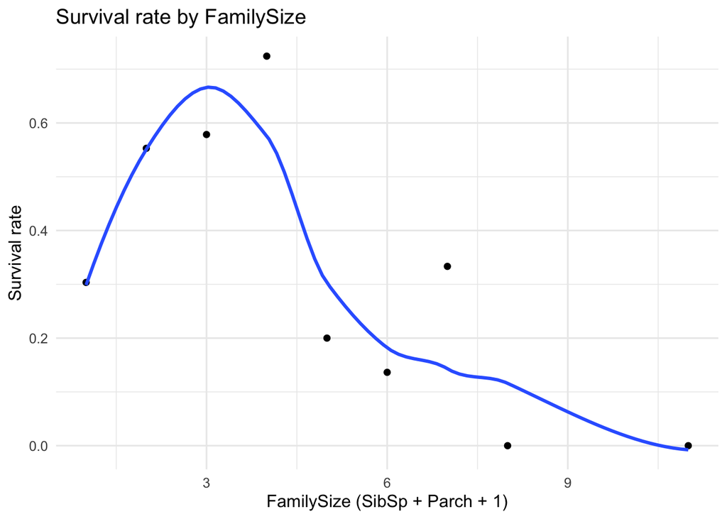

```r
# Survival rate by FamilySize
eda_family <- train %>%
  group_by(FamilySize) %>%
  summarize(n = n(), surv_rate = mean(Survived == "Yes"), .groups = "drop")

ggplot(eda_family, aes(FamilySize, surv_rate)) +
  geom_point() + geom_smooth(method = "loess", se = FALSE) +
  labs(title = "Survival rate by FamilySize",
       x = "FamilySize (SibSp + Parch + 1)", y = "Survival rate") +
  theme_base
```

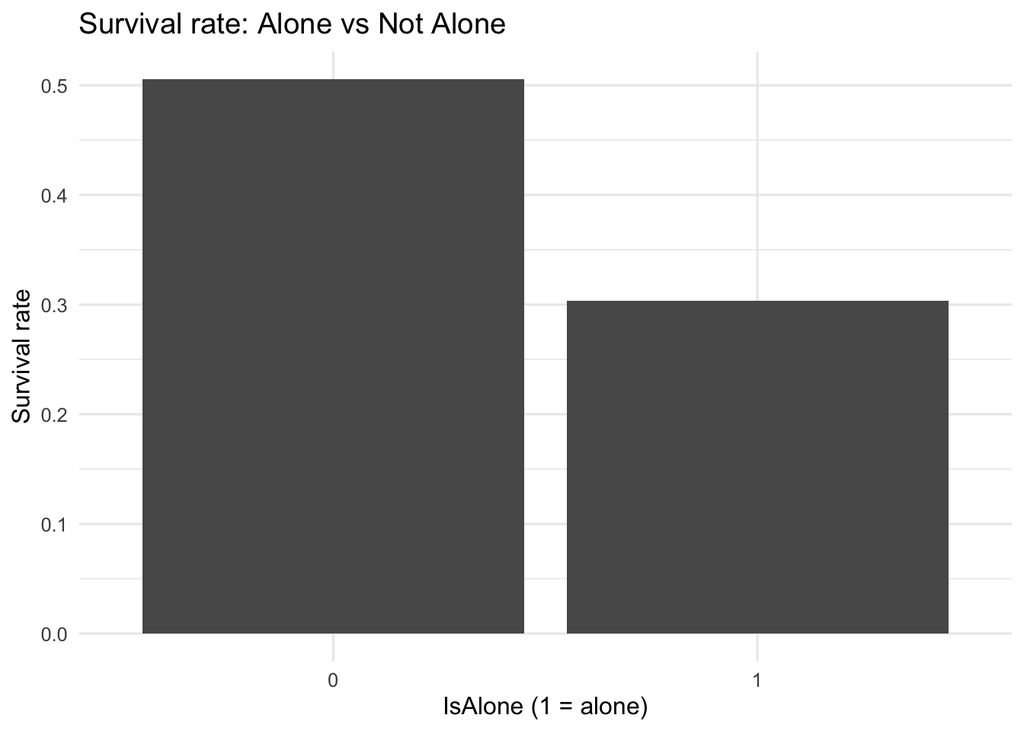

```r
# Survival rate by IsAlone
eda_alone <- train %>%
  group_by(IsAlone) %>%
  summarize(n = n(), surv_rate = mean(Survived == "Yes"), .groups = "drop")

ggplot(eda_alone, aes(factor(IsAlone), surv_rate)) +
  geom_col() +
  labs(title = "Survival rate: Alone vs Not Alone",
       x = "IsAlone (1 = alone)", y = "Survival rate") +
  theme_base
```

## Models: Baseline vs Group features

We compare a baseline logistic regression (Sex, Pclass, Age, Fare) to a model adding GroupSize, FamilySize, IsAlone. We perform 5-fold cross-validation and report accuracy and ROC AUC.

```r
set.seed(42)
folds <- vfold_cv(train, v = 5, strata = Survived)

cv_metrics <- function(df, formula) {
  map_dfr(folds$splits, function(s) {
    tr <- analysis(s)
    te <- assessment(s)
    fit <- glm(formula, data = tr, family = binomial())
    prob <- predict(fit, newdata = te, type = "response")
    pred <- factor(ifelse(prob > 0.5, "Yes", "No"), levels = c("No","Yes"))
    tibble(
      accuracy = yardstick::accuracy_vec(te$Survived, pred),
      roc_auc = yardstick::roc_auc_vec(te$Survived, prob, event_level = "second")
    )
  }) %>% summarize(across(everything(), mean))
}

baseline_formula <- Survived ~ Sex + Pclass + Age + Fare
group_formula    <- Survived ~ Sex + Pclass + Age + Fare + GroupSize + FamilySize + IsAlone

metrics_baseline <- cv_metrics(train, baseline_formula)
metrics_group    <- cv_metrics(train, group_formula)

bind_rows(
  metrics_baseline %>% mutate(model = "Baseline"),
  metrics_group %>% mutate(model = "+Groups")
) %>% select(model, accuracy, roc_auc) %>% knitr::kable(digits = 3)
```

| model | accuracy | roc_auc |
| --- | --- | --- |
| Baseline | 0.798 | 0.847 |
| +Groups | 0.804 | 0.850 |

# 2) Women and children first once you include class

## EDA: Survival by Sex × Age band and Sex × Pclass

We explore whether the principle of women and children first holds across passenger classes.

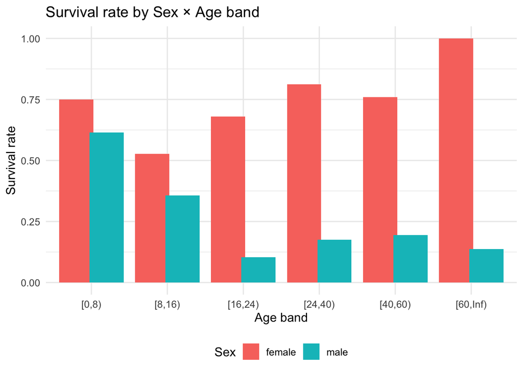

```r
# Age bands
train <- train %>% mutate(AgeBand = cut(Age, breaks = c(0, 8, 16, 24, 40, 60, Inf), right = FALSE))

# Survival by Sex × AgeBand
eda_sex_age <- train %>%
  group_by(Sex, AgeBand) %>%
  summarize(n = n(), surv_rate = mean(Survived == "Yes"), .groups = "drop")

ggplot(eda_sex_age, aes(AgeBand, surv_rate, fill = Sex)) +
  geom_col(position = position_dodge(width = 0.8)) +
  labs(title = "Survival rate by Sex × Age band",
       x = "Age band", y = "Survival rate") +
  theme_base
```

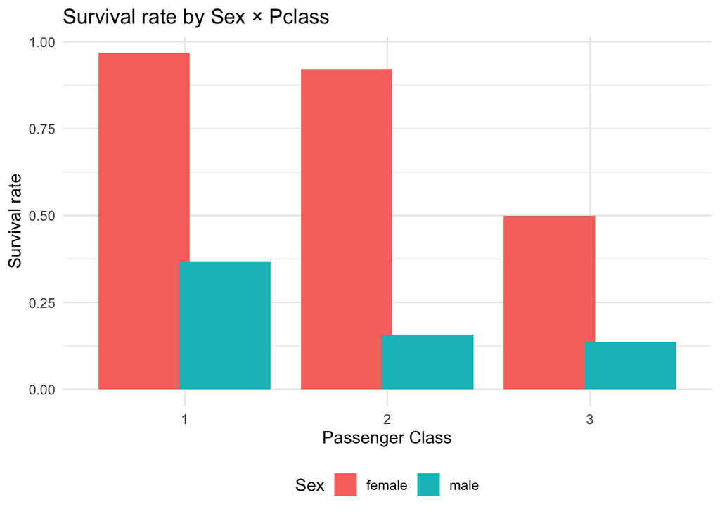

```r
# Survival by Sex × Pclass
eda_sex_pclass <- train %>%
  group_by(Sex, Pclass) %>%
  summarize(n = n(), surv_rate = mean(Survived == "Yes"), .groups = "drop")

ggplot(eda_sex_pclass, aes(Pclass, surv_rate, fill = Sex)) +
  geom_col(position = position_dodge(width = 0.8)) +
  labs(title = "Survival rate by Sex × Pclass",
       x = "Passenger Class", y = "Survival rate") +
  theme_base
```

## Models: Logistic regression with interactions vs tree

We fit logistic regression with interaction terms Sex*Child and Sex*Pclass, and compare to a tree-based model (rpart). We perform 5-fold CV and compare metrics.

```r
library(rpart)
library(rpart.plot)
set.seed(42)
folds <- vfold_cv(train, v = 5, strata = Survived)

cv_models <- function(df) {
  map_dfr(folds$splits, function(s) {
    tr <- analysis(s)
    te <- assessment(s)
    # Logistic with interactions
    fit_logit <- glm(Survived ~ Sex * Child + Sex * Pclass + Age + Fare, data = tr, family = binomial())
    prob_logit <- predict(fit_logit, newdata = te, type = "response")
    pred_logit <- factor(ifelse(prob_logit > 0.5, "Yes", "No"), levels = c("No","Yes"))

    # Tree model
    fit_tree <- rpart(Survived ~ Sex + Child + Pclass + Age + Fare + FamilySize + GroupSize,
                      data = tr, method = "class", control = rpart.control(cp = 0.01))
    prob_tree <- predict(fit_tree, newdata = te, type = "prob")[,"Yes"]
    pred_tree <- factor(ifelse(prob_tree > 0.5, "Yes", "No"), levels = c("No","Yes"))

    tibble(
      model = c("Logit_int", "Tree"),
      accuracy = c(yardstick::accuracy_vec(te$Survived, pred_logit), yardstick::accuracy_vec(te$Survived, pred_tree)),
      roc_auc = c(yardstick::roc_auc_vec(te$Survived, prob_logit, event_level = "second"), yardstick::roc_auc_vec(te$Survived, prob_tree, event_level = "second"))
    )
  }) %>% group_by(model) %>% summarize(across(c(accuracy, roc_auc), mean), .groups = "drop")
}

model_metrics <- cv_models(train)

model_metrics %>% knitr::kable(digits = 3)
```

| model | accuracy | roc_auc |
| --- | --- | --- |
| Logit_int | 0.796 | 0.852 |
| Tree | 0.820 | 0.825 |

```r
# Interpret key effects for logistic model on full data
fit_logit_full <- glm(Survived ~ Sex * Child + Sex * Pclass + Age + Fare, data = train, family = binomial())
tidy(fit_logit_full, exponentiate = TRUE, conf.int = TRUE) %>%
  arrange(desc(estimate)) %>%
  knitr::kable(digits = 3, caption = "Odds ratios with 95% CI: key effects")
```

Odds ratios with 95% CI: key effects

| term | estimate | std.error | statistic | p.value | conf.low | conf.high |
| --- | --- | --- | --- | --- | --- | --- |
| (Intercept) | 104.395 | 0.770 | 6.034 | 0.000 | 26.109 | 566.033 |
| Sexmale:Child | 6.394 | 0.534 | 3.475 | 0.001 | 2.231 | 18.195 |
| Sexmale:Pclass3 | 6.362 | 0.675 | 2.742 | 0.006 | 1.921 | 29.283 |
| Fare | 0.999 | 0.002 | -0.374 | 0.709 | 0.994 | 1.004 |
| Age | 0.970 | 0.010 | -2.996 | 0.003 | 0.950 | 0.989 |
| Child | 0.639 | 0.439 | -1.020 | 0.308 | 0.270 | 1.520 |
| Sexmale:Pclass2 | 0.579 | 0.812 | -0.672 | 0.502 | 0.123 | 3.234 |
| Pclass2 | 0.303 | 0.758 | -1.572 | 0.116 | 0.059 | 1.270 |
| Pclass3 | 0.021 | 0.673 | -5.764 | 0.000 | 0.004 | 0.067 |
| Sexmale | 0.020 | 0.626 | -6.254 | 0.000 | 0.005 | 0.058 |

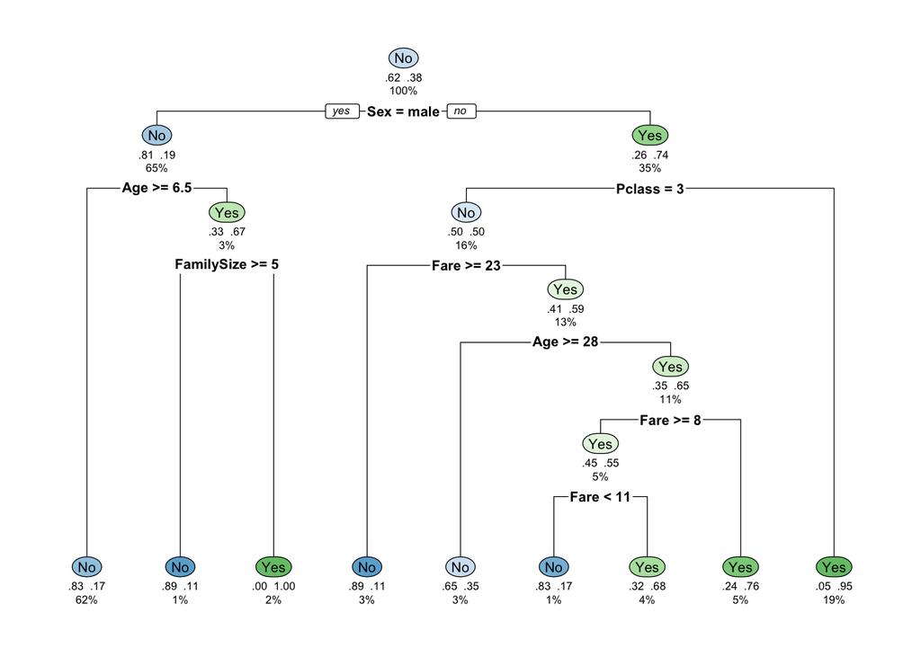

```r
# Visualize tree for full data
fit_tree_full <- rpart(Survived ~ Sex + Child + Pclass + Age + Fare + FamilySize + GroupSize,
                      data = train, method = "class", control = rpart.control(cp = 0.01))
rpart.plot(fit_tree_full, type = 2, extra = 104, under = TRUE, fallen.leaves = TRUE)
```

# Notes and Assumptions

- Age imputation uses median within Sex × Pclass groups; if a group is entirely missing, fall back to global median. This keeps information leakage minimal, as imputation is performed before cross-validation and uses stratified attributes rather than outcome.
- GroupSize uses Ticket string as proxy for travel group; this may include unrelated people sharing ticket numbers, but serves as a reasonable proxy in the Kaggle Titanic dataset.
- We report mean CV accuracy and ROC AUC to compare models.